# Estudios de Informática, Multimedia y Telecomunicaciones

# Estadística Avançada

Autor: Jordi Puig Ovejero

Març 2021

Carrega de les llibreries que es necessiten

```r
library(dplyr)
library(base)
library(matrixStats)
library(stringr)
library(ggplot2)
library(lubridate)
library(eeptools)
library(psych)
library(corrplot)
library(factoextra)
library(ggbiplot)
```

# 1 Càrrega del fitxer

El fitxer on es troba el dataset és, **fifa_raw.csv**:

Carreguem les dades i fem un summary de les dades que ens demana l’activitat. Els elements categòrics estan carregats com a *factor* des d’un inici. L’encoding com a UTF-8 ja que tenim accents i altres caràcters que requereixen aquesta codificació.

```r
fifa <- read.csv('fifa_raw.csv',stringsAsFactors = TRUE, sep = ',', encoding="UTF-8")
fifa.tmp <- fifa[,c('Name', 'Nationality', 'Club_Joining', 'Contract_Expiry', 'Rating', 'Height', 'Weight', 'Preffered_Foot', 'Birth_Date', 'Age', 'Work_Rate')]

attach(fifa) # ens permet referenciar les columnes de fifa sense haver d'especificar el dataset.

summary(fifa.tmp)
```

```
##          Name          Nationality        Club_Joining   Contract_Expiry
##  Danilo    :    5   England  : 1530   07/01/2016: 1193   Min.   :2017
##  Gabriel   :    5   Argentina: 1029   07/01/2015:  907   1st Qu.:2017
##  Felipe    :    4   Spain    :  945   07/01/2014:  558   Median :2019
##  Roberto   :    4   France   :  927   01/01/2016:  412   Mean   :2019
##  Álvaro    :    3   Brazil   :  874   07/01/2013:  404   3rd Qu.:2020
##  Ben Davies:    3   Italy    :  699   01/01/2015:  391   Max.   :2023
##  (Other)   :17564   (Other)  :11584   (Other)   :13723   NA's   :1
##      Rating          Height            Weight      Preffered_Foot
##  Min.   :45.00   180 cm : 1521   70.522 kg:    7   Min.   :1.000
##  1st Qu.:62.00   178 cm : 1187   79.229 kg:    7   1st Qu.:2.000
##  Median :66.00   185 cm : 1183   69.541 kg:    6   Median :2.000
##  Mean   :66.17   183 cm : 1116   70.411 kg:    6   Mean   :1.767
##  3rd Qu.:71.00   175 cm : 1033   70.671 kg:    6   3rd Qu.:2.000
##  Max.   :94.00   (Other):11545   (Other)  :17553   Max.   :2.000
##                  NA's   :    3   NA's     :    3
##       Birth_Date         Age                  Work_Rate
##  02/29/1988:  160   Min.   :17.00   Medium / Medium:9629
##  02/29/1984:  157   1st Qu.:22.00   High / Medium  :2832
##  02/29/1992:  155   Median :25.00   Medium / High  :1534
##  01/01/1996:   13   Mean   :25.46   Medium / Low   : 845
##  11/11/1996:   13   3rd Qu.:29.00   High / High    : 747
##  01/08/1991:   12   Max.   :47.00   High / Low     : 730
##  (Other)   :17078                   (Other)        :1271
```

Contem les files i columnes que tenim.

```r
ncol(fifa)
```

```
## [1] 54
```

```r
nrow(fifa.tmp)
```

```
## [1] 17588
```

```r
ncol(fifa.tmp)
```

```
## [1] 11
```

I mostrem els valors NA per cada atribut.

```r
colSums(is.na(fifa.tmp))
```

```
##            Name     Nationality    Club_Joining Contract_Expiry          Rating
##               0               0               0               1               0
##          Height          Weight  Preffered_Foot      Birth_Date             Age
##               3               3               0               0               0
##       Work_Rate
##               0
```

Finalment fem un head dels atributs a tractar.

```r
head(fifa.tmp)
```

```
##                Name Nationality Club_Joining Contract_Expiry Rating Height
## 1 Cristiano Ronaldo    Portugal   07/01/2009            2021     94 1,85 m
## 2      Lionel Messi   Argentina   07/01/2004            2018     93   <NA>
## 3            Neymar      Brazil   07/01/2013            2021     92 1,74 m
## 4       Luis Suárez     Uruguay   07/11/2014            2021     92 1,82 m
## 5      Manuel Neuer     Germany   07/01/2011            2021     92 1,93 m
## 6            De Gea       Spain   07/01/2011            2019     90   <NA>
##      Weight Preffered_Foot Birth_Date Age       Work_Rate
## 1      <NA>              2 02/05/1985  32      High / Low
## 2  72475 gr              1 06/24/1987  29 Medium / Medium
## 3  68884 gr              2 02/05/1992  25   High / Medium
## 4  85511 gr              2 01/24/1987  30   High / Medium
## 5      <NA>              2 03/27/1986  31 Medium / Medium
## 6 82.671 kg              2 11/07/1990  26 Medium / Medium
```

Amb una ràpida ullada podem dir que:

- Nombre de registres: 17588
- Nombre d’atributs totals: 54
- Nombre d’atributs: 11
- Tenim valors NA a Contract_Expiry, Height i Weight.
- Preffered_Foot és un categòric ocult com a quantitatiu.
- Les dades numèriques sembla que están en el format desitjat excepte Height. Separació de decimals amb el punt.
- Les dates están com a categòriques, les haurem de canviar i el mateix passa amb el camp age, height o weight.
- A Weight tenim dades en kilograms i grams.
- A Height tenim dades en centimetres i metres.

## 1.1 Definició dels atributs

- 1 - Name (Nom del jugador)
- 2 - Nationality (Nacionalitat del jugador)
- 3 - Club_Joining (Data que va començar al club)
- 4 - Contract_Expire (Any finalització del contracte)
- 5 - Rating (Valoració global del jugador, entre 0 i 100)
- 6 - Height (Altura)
- 7 - Weight (Pes)
- 8 - Preffered_Foot (Peu preferit)
- 9 - Birth_Date (Data de naixement)
- 10 - Age (Edat)
- 11 - Work_Rate (valoració qualitativa en termes d’atac-defensa)

# 2 Verificar duplicació de registres

Anem a eliminar els registres duplicats segons el camp ID i ens quedarem aquells que tinguin menys valors NA.

```r
# busquem els duplicats i els afegim a una columna nova com a TRUE si hi ha duplicat i FALSE altrament
fifa$duplicated = duplicated(fifa$ID)

# agafem el subconjunt dels que son duplicats
subset(fifa, duplicated=="TRUE")
```

```
##  [1] ID                 Name               Nationality        National_Position
##  [5] National_Kit       Club               Club_Position      Club_Kit
##  [9] Club_Joining       Contract_Expiry    Rating             Height
## [13] Weight             Preffered_Foot     Birth_Date         Age
## [17] Preffered_Position Work_Rate          Weak_foot          Skill_Moves
## [21] Ball_Control       Dribbling          Marking            Sliding_Tackle
## [25] Standing_Tackle    Aggression         Reactions          Attacking_Position
## [29] Interceptions      Vision             Composure          Crossing
## [33] Short_Pass         Long_Pass          Acceleration       Speed
## [37] Stamina            Strength           Balance            Agility
## [41] Jumping            Heading            Shot_Power         Finishing
## [45] Long_Shots         Curve              Freekick_Accuracy  Penalties
## [49] Volleys            GK_Positioning     GK_Diving          GK_Kicking
## [53] GK_Handling        GK_Reflexes        duplicated
## <0 rows> (or 0-length row.names)
```

```r
# sembla que no en tenim però farem una altre comprovació

# creem una variable amb els valors de ID
ID <- fifa$ID
# creem una taula amb les ocurrencies de cada element ordenades
table <- as.data.frame(table(ID))
head(sort(table$Freq,decreasing=TRUE), n = 5)
```

```
## [1] 1 1 1 1 1
```

Concluïm doncs que no tenim duplicacions en la variable ID.

# 3 Normalització de les dades quantitatives

Anem a normalitzar les dades quantitatives.

## 3.1 Rating

Comprovarem que:

- la variable sigui quantitativa.
- si té decimals que el símbol sigui el punt.
- que es trobi normalitzada dins dels valors 0 - 100.

```r
class(fifa$Rating)
```

```
## [1] "integer"
```

```r
summary(fifa$Rating)
```

```
##    Min. 1st Qu.  Median    Mean 3rd Qu.    Max.
##   45.00   62.00   66.00   66.17   71.00   94.00
```

```r
head(fifa$Rating)
```

```
## [1] 94 93 92 92 92 90
```

Amb el class, veiem que el valor és un Integer. És un quantitatiu discret. Amb el summary que hem fet veiem que està correctament normalitzada ja que el valor màxim és el 94 i el mínim 45.

## 3.2 Height

Comprovarem que:

- la variable sigui quantitativa.
- expressada en cm amb 3 dígits sense decimals
- sense el símbol de cm o m.

```r
class(fifa$Height)
```

```
## [1] "factor"
```

```r
head(fifa$Height)
```

```
## [1] 1,85 m <NA>   1,74 m 1,82 m 1,93 m <NA>
## 80 Levels: 1,67 m 1,68 m 1,7 m 1,71 m 1,72 m 1,73 m 1,74 m 1,75 m ... 207 cm
```

La variable al ser string s’ha carregat com a Factor. Abans de transformar-la a numérica anem a eliminar el string ’ m’ i ’ cm’. El valors en metres els passarem a cm i finalment fem un cast a Integer.

```r
# eliminem el string (' m')
fifa$Height <- str_replace(fifa$Height, " m", "")

# eliminem el string (' cm')
fifa$Height <- str_replace(fifa$Height, " cm", "")

# passem la coma a punt i convertim en numèric
fifa$Height <- str_replace(fifa$Height, ",", ".")

fifa$Height <- as.numeric(fifa$Height)
class(fifa$Height)
```

```
## [1] "numeric"
```

```r
summary(fifa$Height)
```

```
##    Min. 1st Qu.  Median    Mean 3rd Qu.    Max.    NA's
##    1.67  176.00  181.00  179.84  186.00  207.00       3
```

```r
# els valors menors de 5 els mmultipliquem per 100 per passar de cm a metres (dono per fet que els valors menors de 5 son cm i els més grans son metres)
fifa$Height <- ifelse(fifa$Height <= 5, fifa$Height * 100, fifa$Height)

# fem un summary i head per veure que tot correcte
summary(fifa$Height)
```

```
##    Min. 1st Qu.  Median    Mean 3rd Qu.    Max.    NA's
##   155.0   176.0   181.0   181.1   186.0   207.0       3
```

```r
head(fifa$Height)
```

```
## [1] 185  NA 174 182 193  NA
```

Si revisem visualment amb un boxplot:

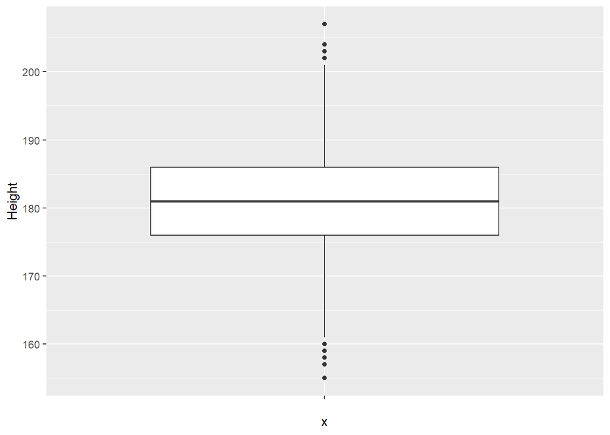

```r
ggplot(data = fifa ,aes(x="",y=Height))+geom_boxplot()
```

Veiem que la conversió ha estat correcte i els extrems que tenim són totalment vàlids com a mesures d’alçada.

## 3.3 Weight

Comprovarem que:

- la variable sigui quantitativa.
- expressada en kg amb 2 dígits sense decimals
- sense el símbol de kg.

```r
class(fifa$Weight)
```

```
## [1] "factor"
```

```r
head(fifa$Weight)
```

```
## [1] <NA>      72475 gr  68884 gr  85511 gr  <NA>      82.671 kg
## 11720 Levels: 100.326 kg 100.396 kg 100.47 kg 100.486 kg 101.673 kg ... 99.729 kg
```

Fent una primera ullada veig que la situació és similar que amb Weight. Estan com a factor (ja que els string els hem carregat com a tal)i tenim valors amb gr. i kg.

```r
# eliminem el string (' gr')
fifa$Weight <- str_replace(fifa$Weight, " gr", "")

# eliminem el string (' kg')
fifa$Weight <- str_replace(fifa$Weight, " kg", "")

# passem la coma a punt i convertim en numèric
fifa$Weight <- str_replace(fifa$Weight, ",", ".")
fifa$Weight <- as.numeric(fifa$Weight)

# els valors menors de 5 els dividim per 1000 per passar de gr a kg (dono per fet que els valors > 1000 son cm i els més petits son metres)
fifa$Weight <- ifelse(fifa$Weight > 1000, fifa$Weight / 1000, fifa$Weight)

# eliminem els decimals truncant
fifa$Weight <- round(fifa$Weight, 0)

# fem un summary i head per veure que tot correcte
summary(fifa$Weight)
```

```
##    Min. 1st Qu.  Median    Mean 3rd Qu.    Max.    NA's
##   48.00   71.00   75.00   75.74   80.00  111.00       3
```

```r
head(fifa$Weight)
```

```
## [1] NA 72 69 86 NA 83
```

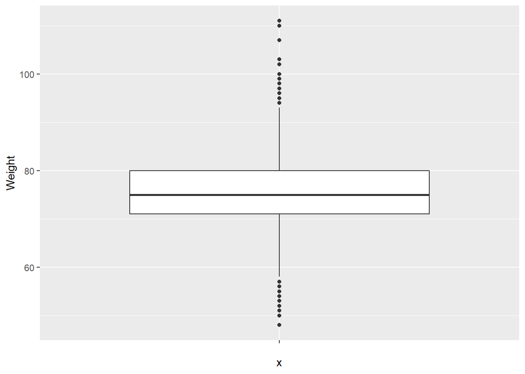

```r
ggplot(data = fifa ,aes(x="",y=Weight))+geom_boxplot()
```

# 4 Normalització de les dades qualitatives

## 4.1 Name i Nationality

Comprovarem que:

- la variable sigui qualitativa.
- sense espais abans o després del seu valor.
- majúscules a la seva primera lletra de cada paraula.

```r
class(fifa$Name)
```

```
## [1] "factor"
```

```r
head(fifa$Name)
```

```
## [1] Cristiano Ronaldo Lionel Messi      Neymar            Luis Suárez
## [5] Manuel Neuer      De Gea
## 17360 Levels:    Aaron ramsey    Alan chaparro    Albert adomah ... Zymer Bytyqi
```

```r
class(fifa$Nationality)
```

```
## [1] "factor"
```

```r
head(fifa$Nationality)
```

```
## [1] Portugal  Argentina Brazil    Uruguay   Germany   Spain
## 315 Levels: Afghanistan Albania ALBANIA algeria Algeria ALGERIA ... Zimbabwe
```

Les dades són qualitatives. Ara eliminem el primers i els darrers espais en blanc si hi han.

```r
fifa$Name <- trimws(fifa$Name)
fifa$Nationality <- trimws(fifa$Nationality)
```

Per posar només la primera lletra de cada paraula a majúscula, primer posem totes a minúscules i després la primera de cada paraula a majúscula.

```r
# passem totes les lletres a lowercase
fifa$Name <- tolower(fifa$Name)
fifa$Nationality <- tolower(fifa$Nationality)

# creem una funció per passar la primera lletra de cada  a uppercase fem servir la funció str_to_title
fifa$Name <- str_to_title(fifa$Name)
fifa$Nationality <- str_to_title(fifa$Nationality)

# revisem que hagi anat tot bé
summary(fifa$Name)
```

```
##    Length     Class      Mode
##     17588 character character
```

```r
head(fifa$Name, 15)
```

```
##  [1] "Cristiano Ronaldo"  "Lionel Messi"       "Neymar"
##  [4] "Luis Suárez"        "Manuel Neuer"       "De Gea"
##  [7] "Robert Lewandowski" "Gareth Bale"        "Zlatan Ibrahimovic"
## [10] "Thibaut Courtois"   "Jérôme Boateng"     "Eden Hazard"
## [13] "Luka Modric"        "Mesut Özil"         "Gonzalo Higuaín"
```

```r
summary(fifa$Nationality)
```

```
##    Length     Class      Mode
##     17588 character character
```

```r
head(fifa$Nationality, 15)
```

```
##  [1] "Portugal"  "Argentina" "Brazil"    "Uruguay"   "Germany"   "Spain"
##  [7] "Poland"    "Wales"     "Sweden"    "Belgium"   "Germany"   "Belgium"
## [13] "Croatia"   "Germany"   "Argentina"
```

```r
# convertim a factor els dos atributs
fifa$Name <- as.factor(fifa$Name)
fifa$Nationality <- (fifa$Nationality)
```

## 4.2 Preffered_Foot

Comprovarem que:

- la variable sigui qualitativa.
- els valors actuals d’1 i 2 han de ser els valors Left i Right respectivament.

```r
class(fifa$Preffered_Foot)
```

```
## [1] "integer"
```

Com es un valor numèric, el convertim a factor i veiem quin valors tenim

```r
fifa$Preffered_Foot <- as.factor(fifa$Preffered_Foot)
summary(fifa$Preffered_Foot)
```

```
##     1     2
##  4094 13494
```

Fem les conversions adhients.

```r
# si es 1 Left, altrament Right
fifa$Preffered_Foot <- ifelse(fifa$Preffered_Foot == "1", "Left", "Right")
# convertim a factor
fifa$Preffered_Foot <- as.factor(fifa$Preffered_Foot)
summary(fifa$Preffered_Foot)
```

```
##  Left Right
##  4094 13494
```

## 4.3 Work_Rate

Comprovarem que:

- la variable sigui qualitativa.
- es basa en la combinació de dos d’aquestes tres categories: Low, Medium i High.

```r
class(fifa$Work_Rate)
```

```
## [1] "factor"
```

```r
head(fifa$Work_Rate)
```

```
## [1] High / Low      Medium / Medium High / Medium   High / Medium
## [5] Medium / Medium Medium / Medium
## 11 Levels: Hig / Med High / High High / Low High / Medium ... Medium / Medium
```

```r
levels(fifa$Work_Rate)
```

```
##  [1] "Hig / Med"       "High / High"     "High / Low"      "High / Medium"
##  [5] "Low / High"      "Low / Low"       "Low / Medium"    "Med / Med"
##  [9] "Medium / High"   "Medium / Low"    "Medium / Medium"
```

Efectivament hi han algun level del factor que no està format per les paraules completes. Anem a modificar-ho.

```r
fifa$Work_Rate <- str_replace(fifa$Work_Rate, "Hig / Med", "High / Medium")
fifa$Work_Rate <- str_replace(fifa$Work_Rate, "Med / Med", "Medium / Medium")
fifa$Work_Rate <- as.factor(fifa$Work_Rate)
levels(fifa$Work_Rate)
```

```
## [1] "High / High"     "High / Low"      "High / Medium"   "Low / High"
## [5] "Low / Low"       "Low / Medium"    "Medium / High"   "Medium / Low"
## [9] "Medium / Medium"
```

# 5 Possibles inconsistències i variables tipus data

## 5.1 Club_Joining

Comprovarem que:

- la variable Club_Joining està en el rang dels anys 1990 a 2017. Si no es compleix, mostrar número de registre, Name i Club_joining.

```r
class(fifa$Club_Joining)
```

```
## [1] "factor"
```

No es data l’anem a transformar en el format.

```r
# mostrem el format inicial dels factor
head(fifa$Club_Joining, 15)
```

```
##  [1] 07/01/2009 07/01/2004 07/01/2013 07/11/2014 07/01/2011 07/01/2011
##  [7] 07/01/2014 09/02/2013 07/01/2016 07/26/2011 07/14/2011 07/01/2012
## [13] 08/01/2012 09/02/2013 07/26/2016
## 1678 Levels:  01/01/1993 01/01/1998 01/01/1999 01/01/2000 ... 12/31/2016
```

```r
fifa$Club_Joining <- as.Date(fifa$Club_Joining, format="%m/%d/%Y")
summary(fifa$Club_Joining)
```

```
##         Min.      1st Qu.       Median         Mean      3rd Qu.         Max.
## "1991-06-01" "2014-07-01" "2015-07-27" "2015-01-23" "2016-07-01" "2017-03-24"
##         NA's
##          "1"
```

Les varibles están entre 1991 i 2017 excepte una que es NA. Anem a veure quina es.

```r
wrong_data <- subset(fifa,is.na(Club_Joining))
wrong_data[,c("ID","Name", "Club_Joining")]
```

```
##      ID          Name Club_Joining
## 384 384 Didier Drogba         <NA>
```

## 5.2 Contract_Expiry >= Club_Joining?

Comprovarem que:

- la variable Contract_Expiry >= Club_Joining. Si no es compleix, mostrarem número de registre, Name, Club_joining i Contract_Expiry.

```r
# mostrem el format inicial dels factor i veiem que només està l'any
head(fifa$Contract_Expiry, 15)
```

```
##  [1] 2021 2018 2021 2021 2021 2019 2021 2022 2017 2019 2021 2020 2020 2018 2021
```

```r
# agafem l'any del club_joining
fifa$club_joining_year <- format(fifa$Club_Joining, format = "%Y")

# passem a integer
fifa$Club_Joining_Year <- as.integer(fifa$club_joining_year)
head(fifa$Club_Joining_Year)
```

```
## [1] 2009 2004 2013 2014 2011 2011
```

```r
# passem a integer el Contract_Expiry
fifa$Contract_Expiry <- as.integer(fifa$Contract_Expiry)

# agafem els registres que l'any de Club_Joining > Contract_Expiry
wrong_data <- subset(fifa,Club_Joining_Year > Contract_Expiry)
wrong_data[,c("ID","Name", "Club_Joining")]
```

```
## [1] ID           Name         Club_Joining
## <0 rows> (or 0-length row.names)
```

```r
# esborrem la columna temporal que hem creat
fifa$Club_Joining_Year <- NULL

# tornem a deixar Contract_Expiry com a Factor
fifa$Contract_Expiry <- as.factor(fifa$Contract_Expiry)
```

No hi ha cap registre on la data de Contract_Expiry < Club_Joining.

## 5.3 Birth_Date. Revisar si l’edat correspon a la data de naixement

Comprovarem que:

- la variable Age sigui de tipus integer.
- la variable Age a la data 1/1/2017 correspon a la calculada amb Birth_Date. Si no es compleix, modifiquem l’edat en funció de la data de naixement.

```r
# la variable Age es integer.
class(fifa$Age)
```

```
## [1] "integer"
```

```r
# veiem com és Birth_Date
head(fifa$Birth_Date)
```

```
## [1] 02/05/1985 06/24/1987 02/05/1992 01/24/1987 03/27/1986 11/07/1990
## 6063 Levels: 01/01/1982 01/01/1983 01/01/1984 01/01/1985 ... 12/31/1998
```

```r
# passem a Data
fifa$Birth_Date <- as.Date(fifa$Birth_Date, format="%m/%d/%Y")
head(fifa$Birth_Date)
```

```
## [1] "1985-02-05" "1987-06-24" "1992-02-05" "1987-01-24" "1986-03-27"
## [6] "1990-11-07"
```

```r
class(fifa$Birth_Date)
```

```
## [1] "Date"
```

```r
# creem la variabla temporal amb la data de càlcul de l'edat
tmp.data <- as.Date('1/1/2017', format="%d/%m/%Y")
tmp.data
```

```
## [1] "2017-01-01"
```

```r
# càlculem l'edat des de la data '1/1/2017'
fifa$age.tmp <-age_calc(fifa$Birth_Date, enddate = tmp.data, units = "years")
head(fifa$age.tmp)
```

```
## [1] 31.90411 29.52329 24.90437 29.93699 30.76712 26.15068
```

```r
# necessitem truncar els anys calculats
class(fifa$age.tmp)
```

```
## [1] "numeric"
```

```r
# veiem els primer elements de les dues columnes
head(fifa[,c("Age","age.tmp", "Birth_Date")])
```

```
##   Age  age.tmp Birth_Date
## 1  32 31.90411 1985-02-05
## 2  29 29.52329 1987-06-24
## 3  25 24.90437 1992-02-05
## 4  30 29.93699 1987-01-24
## 5  31 30.76712 1986-03-27
## 6  26 26.15068 1990-11-07
```

Veient el elements comprovem que la variable Age no té l’edat del jugador en la data 1-1-2017. Sembla que s’hagi agafat la mostra en una altre data posterior al 1-1-2017. Anem a arreglar-ho.

```r
# passem a integer i així eliminem els decimals.
fifa$age.tmp <- as.integer(fifa$age.tmp)
head(fifa$age.tmp)
```

```
## [1] 31 29 24 29 30 26
```

```r
# substituim els valors inicials per els calculats.
fifa$Age <- fifa$age.tmp

# esborrem la columna temporal.
fifa$age.tmp <- NULL

# ja tenim l'edat correcte.
head(fifa$Age)
```

```
## [1] 31 29 24 29 30 26
```

# 6 Valors atípics

Anem a revisar els valors atípics de Height i Weight encara que ja tenim una petita idea a partir d’un apartat previ.

## 6.1 Outliers a Height

```r
summary(fifa$Height)
```

```
##    Min. 1st Qu.  Median    Mean 3rd Qu.    Max.    NA's
##   155.0   176.0   181.0   181.1   186.0   207.0       3
```

Fent un summary veiem que els valor màxim es de 207cm. i el mínim 155cm. Els dos són dos valors molt vàlids. També tenim 3 NA que ja els resoldrem més endavant.

Per a trobar valors extrems anem a aplicar la idea dels IQR (interquartile ranges):

- [referència1:](http://www.mathwords.com/o/outlier.htm)
- [referència2:](http://r-statistics.co/Outlier-Treatment-With-R.html)

Per a una determinada variable contínua, els outliers són aquelles observacions que es troben fora de 1.5 * IQR, on IQR, el “Inter Quartile Range” és la diferència entre el Q3 i el Q1:

- Interquartile range, IQR = Q3 - Q1
- lower = Q1 - 1.5 * IQR
- Upper = Q3 + 1.5 * IQR

Creem una funció que ens digui els límits dels valors atípics de la nostre mostra.

```r
outliersLimits <- function(x) {
    limits <- c("above", "under")
    limits$above <- quantile(x, 0.75, type=6) + 1.5 * (quantile(x, 0.75, type=6) - quantile(x, 0.25, type=6))
    limits$under <- quantile(x, 0.25, type=6) - 1.5 * (quantile(x, 0.75, type=6) - quantile(x, 0.25, type=6))
  return(limits)
}

# Eliminem el NA ja que no ens serveixen per a calcular els límits.

Height.clean <- na.omit(fifa$Height)

Height.limits <- outliersLimits(Height.clean)

paste("Límit inferior:", Height.limits$under)
```

```
## [1] "Límit inferior: 161"
```

```r
paste("Límit superior:", Height.limits$above)
```

```
## [1] "Límit superior: 201"
```

Segons el càlcul el límit de inferior seria 161 (mínim de la mostra és 155.0) i el límit superior 201 (màxim de la mostra és 207.0).

Anem a mostrar amb el BoxPlot on podem veure en forma de punts, els valors superiors a 201 i inferiors a 161, que hem calculat.

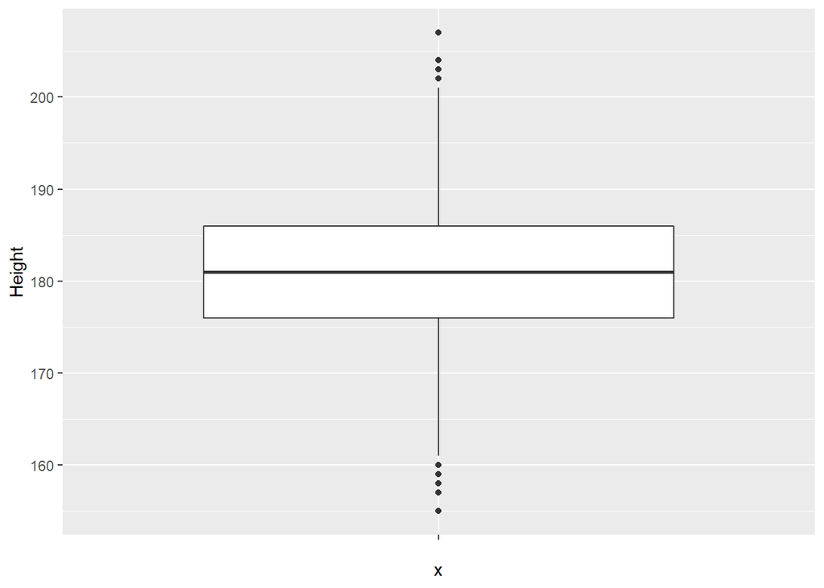

```r
ggplot(data = fifa ,aes(x="",y=Height))+geom_boxplot()
```

Com a exercici anem a esborrar aquests valors i mostrar altre cop el boxplot però realment no vaig a eliminar aquests valors ja que són valors perfectament vàlids en alçades de jugadors.

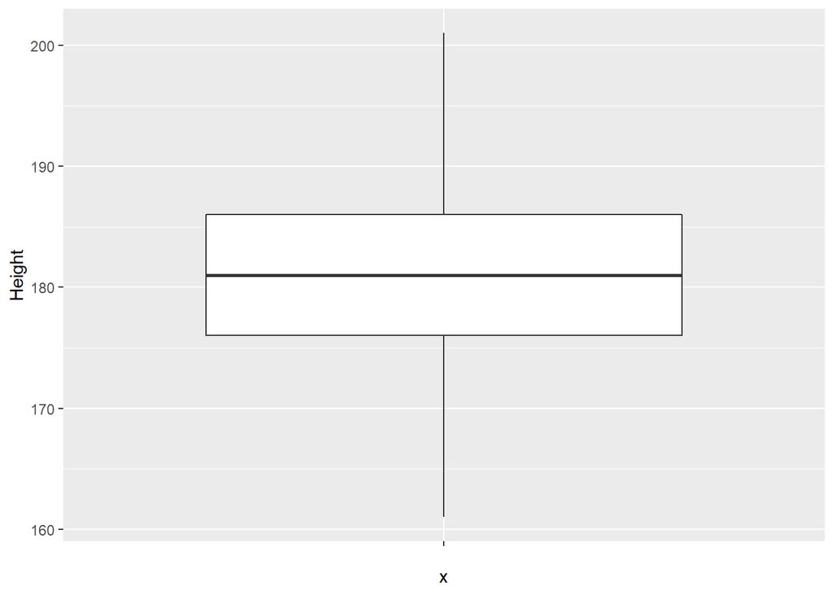

```r
fifa.nooutliers <-subset(fifa, Height >= Height.limits$under)
fifa.nooutliers <-subset(fifa.nooutliers, Height <= Height.limits$above)

ggplot(data = fifa.nooutliers,aes(x="",y=Height))+geom_boxplot()
```

Veiem el bloxpot sense els outliers de Height.

## 6.2 Outliers a Weight

Anem a fer el mateix exercici però amb Weight.

```r
summary(fifa$Weight)
```

```
##    Min. 1st Qu.  Median    Mean 3rd Qu.    Max.    NA's
##   48.00   71.00   75.00   75.74   80.00  111.00       3
```

```r
# Eliminem els NA.

Weight.clean <- na.omit(fifa$Weight)

Weight.limits <- outliersLimits(Weight.clean)
paste("Límit inferior:", Weight.limits$under)
```

```
## [1] "Límit inferior: 57.5"
```

```r
paste("Límit superior:", Weight.limits$above)
```

```
## [1] "Límit superior: 93.5"
```

Mostrem els outliers amb el boxplot. Son els que es veuen un cop acaben les líneas i començen els punts.

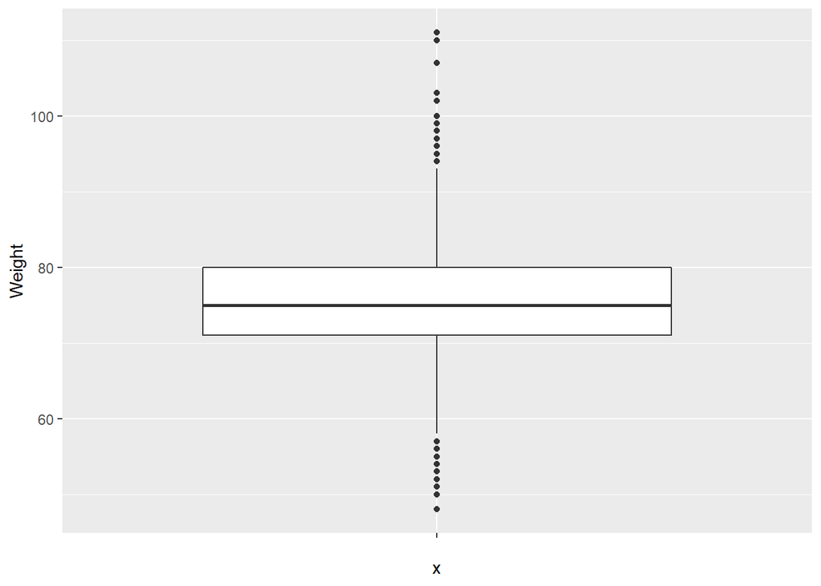

```r
ggplot(data = fifa ,aes(x="",y=Weight))+geom_boxplot()
```

Vaig a veure quins són els jugadors que están en aquests outliers.

```r
fifa.outliers.under <-subset(fifa, Weight < Weight.limits$under)
fifa.outliers.above <-subset(fifa.nooutliers, Weight > Weight.limits$above)


df.under <-fifa.outliers.under[order(fifa.outliers.under$Weight),]
head(df.under[,c("Name","Weight")], 5)
```

```
##                         Name Weight
## 15936            Julius Kade     48
## 12599          Khaled Dakhil     50
## 16296 Abdulmajeed Al Mutairi     50
## 13994      Bandar Al Mutairi     51
## 7910             Diego Rojas     52
```

```r
df.above <-fifa.outliers.above[order(fifa.outliers.above$Weight, decreasing = TRUE),]
head(df.above[,c("Name","Weight")], 5)
```

```
##                    Name Weight
## 11629 Adebayo Akinfenwa    110
## 7317        Chris Seitz    107
## 1806         Bill Hamid    103
## 13129      Hakeem Araba    103
## 15027    Rene Gilmartin    102
```

Fent unes comprovacions a internet he comprovat que els valors outliers-superiors són valors correctes. Els jugadors tenen aquest pes. Amb els inferiors, els extrems, per exemple, Julius Kade amb 48.11kg. o Abdulmajeed Al Mutairi amb 49.55kg si que sembla un error d’introducció de la dada però potser quan es van extreure les dades tenien aquest pes. No són outliers molt extrems que podem deliberadament esborrar.

# 7 Imputació de valors

Tenim valors NA’s a les variables Height i Weight. Anem a realitzar imputació de valors mitjançant predicció dels valors que no tenim a partir d’un model de regressió. Per a predir la variable Height farem servir com a covariables la dada de Weight i per a predir les de Weight farem servir la de Height.

## 7.1 Height

```r
lineal.model <- lm(Height ~ Weight, data= fifa)
I <- is.na(Height)
prediction <- predict(lineal.model, newdata = fifa[I, ])
prediction
```

```
##        2        6        9
## 178.3700 186.4032 195.1666
```

```r
fifa$Height[2] <- round(179, 0)
fifa$Height[6] <- round(186, 0)
fifa$Height[9] <- round(196, 0)
```

Mostrem la imputació (Height) a partir de la variable explicativa (Weight)

```r
cat("Imputació registre 2:",fifa$Height[2] , "cm. - Variable explicativa: " , fifa$Weight[2], "kg\n")
```

```
## Imputació registre 2: 179 cm. - Variable explicativa:  72 kg
```

```r
cat("Imputació registre 6:",fifa$Height[6] , "cm. - Variable explicativa: " , fifa$Weight[6], "kg\n")
```

```
## Imputació registre 6: 186 cm. - Variable explicativa:  83 kg
```

```r
cat("Imputació registre 9:",fifa$Height[9] , "cm. - Variable explicativa: " , fifa$Weight[9], "kg")
```

```
## Imputació registre 9: 196 cm. - Variable explicativa:  95 kg
```

Observem que la imputació de l’alçada és en funció del pes. Com més alt pressuposem més kilograms.

## 7.2 Weight

```r
lineal.model <- lm(Weight ~ Height, data= fifa)
I <- is.na(Weight)
prediction <- predict(lineal.model, newdata = fifa[I, ])
prediction
```

```
##        1        5        7
## 78.79389 85.05655 78.79389
```

Amb la predicció que hem realitzat hem imputat els valors 78.8, 85.06, 78.8, per a els registres 1,5,7 respectivament. Anem a afegir-los al dataset.

```r
fifa$Weight[1] <- round(78.8, 0)
fifa$Weight[5] <- round(85.1, 0)
fifa$Weight[7] <- round(78.8, 0)
```

Ens queda doncs aquesta imputació (Weight) amb la variable explicativa (Height)

```r
cat("Imputació registre 1:",fifa$Weight[1] , "kg. - Variable explicativa: " , fifa$Height[1], "cm\n")
```

```
## Imputació registre 1: 79 kg. - Variable explicativa:  185 cm
```

```r
cat("Imputació registre 5:",fifa$Weight[5] , "kg. - Variable explicativa: " , fifa$Height[5], "cm\n")
```

```
## Imputació registre 5: 85 kg. - Variable explicativa:  193 cm
```

```r
cat("Imputació registre 7:",fifa$Weight[7] , "kg. - Variable explicativa: " , fifa$Height[7], "cm")
```

```
## Imputació registre 7: 79 kg. - Variable explicativa:  185 cm
```

També veiem que la predicció del pes va en funció (dependencia lineal) de l’alçada.

# 8 Estudi descriptiu de les variables quantitatives.

En aquest estudi anem a mostrar tant la tendència central com la dispersió de mesures d’estadística robusta i no robusta. Les mesures robustes són més ressistents als efectes dels valors atípics.

- Tendencia central:
  - Mitjana aritmètica (no-robust): no esbiaixat però molt afectat per els atípics.
  - Mediana (robust): molt fiable per a la tendència central.
  - Mitjana-retallada: eliminem un % de outliers i calculem la mitjanana aritmètica.
  - Mitjana-retallada (winsoritzada): els valors eliminar són substituïts per altres que no generin tanta dispersión en les dades i per tant tendència central més reals.

Crearem un dataset buït per enregistrar els valors.

```r
# calculem les mesures de tendència central per a Height
height.mean <- mean(fifa$Height)
height.median <- median(fifa$Height)
height.trim <- mean(fifa$Height, trim=0.05)
height.trim.winsor <- winsor.mean(fifa$Height, trim=0.05)

centraltendency.height.row <- c(height.mean, height.median, height.trim, height.trim.winsor)
centraltendency.height.row
```

```
## [1] 181.1056 181.0000 181.1112 181.1001
```

```r
# calculem les mesures de tendència central per a Weight
weight.mean <- mean(fifa$Weight)
weight.median <- median(fifa$Weight)
weight.trim <- mean(fifa$Weight, trim=0.05)
weight.trim.winsor <- winsor.mean(fifa$Weight, trim=0.05)

centraltendency.weight.row <- c(weight.mean, weight.median, weight.trim, weight.trim.winsor)

centraltendency.weight.row
```

```
## [1] 75.74528 75.00000 75.65123 75.73607
```

```r
# calculem les mesures de tendència central per a Age
age.mean <- mean(fifa$Age)
age.median <- median(fifa$Age)
age.trim <- mean(fifa$Age, trim=0.05)
age.trim.winsor <- winsor.mean(fifa$Age, trim=0.05)

centraltendency.age.row <- c(age.mean, age.median, age.trim, age.trim.winsor)
centraltendency.age.row
```

```
## [1] 25.14413 25.00000 24.99267 25.04338
```

```r
# calculem les mesures de tendència central per a Rating
rating.mean <- mean(fifa$Rating)
rating.median <- median(fifa$Rating)
rating.trim <- mean(fifa$Rating, trim=0.05)
rating.trim.winsor <- winsor.mean(fifa$Rating, trim=0.05)

centraltendency.rating.row <- c(rating.mean, rating.median, rating.trim, rating.trim.winsor)

# concatenem els vectors dels càlculs per a cada atribut
vectors <- rbind(as.vector(centraltendency.height.row), as.vector(centraltendency.weight.row), as.vector(centraltendency.age.row),as.vector(centraltendency.rating.row))

# construïm el dataset
df.centraltendency <- as.data.frame(vectors)

# afegim el header names
colnames(df.centraltendency)<- c('Mean', 'Median', 'Trim', 'Trim.Windsor')

# afegim row names
rownames(df.centraltendency)<- c('Height', 'Weight', 'Age', 'Rating')

df.centraltendency
```

```
##             Mean Median      Trim Trim.Windsor
## Height 181.10564    181 181.11118    181.10007
## Weight  75.74528     75  75.65123     75.73607
## Age     25.14413     25  24.99267     25.04338
## Rating  66.16619     66  66.16361     66.14726
```

Com podem observar els valors de la tendència central en els 4 atributs són molt similars. Això es deu a que no tenim uns valors atípics o outliers molt grans.

- Dispersió:
  - Desviació estandard (no-robust): afectat per els atípics.
  - RIC - El rang interquartílic (robust): diferència entre el Q3 (percentil 75 %) i el Q1 (percentil 25 %) de les dades. El tamany de la caixa boxplot.
  - DAM - Desviació absoluta respecte de la mediana (robust): semblant a la desviació standard però fa servir la mediana.

```r
# calculem les mesures de dispersió per a Height
height.sdev <- sd(fifa$Height)
height.ric <- IQR(fifa$Height)
height.ram <- mad(fifa$Height)

dispersion.height.row <- c(height.sdev, height.ric, height.ram)
dispersion.height.row
```

```
## [1]  6.674276 10.000000  7.413000
```

```r
# calculem les mesures de dispersió per a Weight
weight.sdev <- sd(fifa$Weight)
weight.ric <- IQR(fifa$Weight)
weight.ram <- mad(fifa$Weight)

dispersion.weight.row <- c(weight.sdev, weight.ric, weight.ram)
dispersion.weight.row
```

```
## [1] 6.909831 9.000000 7.413000
```

```r
# calculem les mesures de dispersió per a Age
age.sdev <- sd(fifa$Age)
age.ric <- IQR(fifa$Age)
age.ram <- mad(fifa$Age)

dispersion.age.row <- c(age.sdev, age.ric, age.ram)
dispersion.age.row
```

```
## [1] 4.676245 7.000000 4.447800
```

```r
# calculem les mesures de dispersió per a Age
age.sdev <- sd(fifa$Age)
age.ric <- IQR(fifa$Age)
age.ram <- mad(fifa$Age)

dispersion.age.row <- c(age.sdev, age.ric, age.ram)
dispersion.age.row
```

```
## [1] 4.676245 7.000000 4.447800
```

```r
# calculem les mesures de dispersió per a Rating
rating.sdev <- sd(fifa$Rating)
rating.ric <- IQR(fifa$Rating)
rating.ram <- mad(fifa$Rating)

dispersion.rating.row <- c(rating.sdev, rating.ric, rating.ram)

# concatenem els vectors dels càlculs per a cada atribut
vectors <- rbind(as.vector(dispersion.height.row), as.vector(dispersion.weight.row), as.vector(dispersion.age.row), as.vector(dispersion.rating.row))

# construïm el dataset
df.dispersion <- as.data.frame(vectors)

# afegim el header names
colnames(df.dispersion)<- c('SDEV', 'IRC', 'DAM')

# afegim row names
rownames(df.dispersion)<- c('Height', 'Weight', 'Age','Rating')

df.dispersion
```

```
##            SDEV IRC    DAM
## Height 6.674276  10 7.4130
## Weight 6.909831   9 7.4130
## Age    4.676245   7 4.4478
## Rating 7.083012   9 7.4130
```

Anem a comprovar la robustesa del IRC i DAM i la no-robustesa de la desviació estandard. Modificarem un registre amb valors atípics per a Age, Weight i Height

```r
# mostrem les dades del primer registre
head(fifa, 1)
```

```
##   ID              Name Nationality National_Position National_Kit        Club
## 1  1 Cristiano Ronaldo    Portugal                LS            7 Real Madrid
##   Club_Position Club_Kit Club_Joining Contract_Expiry Rating Height Weight
## 1            LW        7   2009-07-01            2021     94    185     79
##   Preffered_Foot Birth_Date Age Preffered_Position  Work_Rate Weak_foot
## 1          Right 1985-02-05  31              LW/ST High / Low         4
##   Skill_Moves Ball_Control Dribbling Marking Sliding_Tackle Standing_Tackle
## 1           5           93        92      22             23              31
##   Aggression Reactions Attacking_Position Interceptions Vision Composure
## 1         63        96                 94            29     85        86
##   Crossing Short_Pass Long_Pass Acceleration Speed Stamina Strength Balance
## 1       84         83        77           91    92      92       80      63
##   Agility Jumping Heading Shot_Power Finishing Long_Shots Curve
## 1      90      95      85         92        93         90    81
##   Freekick_Accuracy Penalties Volleys GK_Positioning GK_Diving GK_Kicking
## 1                76        85      88             14         7         15
##   GK_Handling GK_Reflexes duplicated club_joining_year
## 1          11          11      FALSE              2009
```

```r
# treballarem sobre una còpia
fifa.copy <- fifa

# canviem el valor del Height x 10
fifa.copy[1,'Height']
```

```
## [1] 185
```

```r
fifa.copy[1,'Height'] <- fifa.copy[1,'Height'] * 10
fifa.copy[1,'Height']
```

```
## [1] 1850
```

```r
# canviem el valor de Weight x 10
fifa.copy[1,'Weight']
```

```
## [1] 79
```

```r
fifa.copy[1,'Weight'] <- fifa.copy[1,'Weight'] * 10
fifa.copy[1,'Weight']
```

```
## [1] 790
```

```r
# canviem el valor de Age x 10
fifa.copy[1,'Age']
```

```
## [1] 31
```

```r
fifa.copy[1,'Age'] <- fifa.copy[1,'Age'] * 10
fifa.copy[1,'Age']
```

```
## [1] 310
```

Ara mostrem els boxplot i veurem clarament els outliers que hem generat.

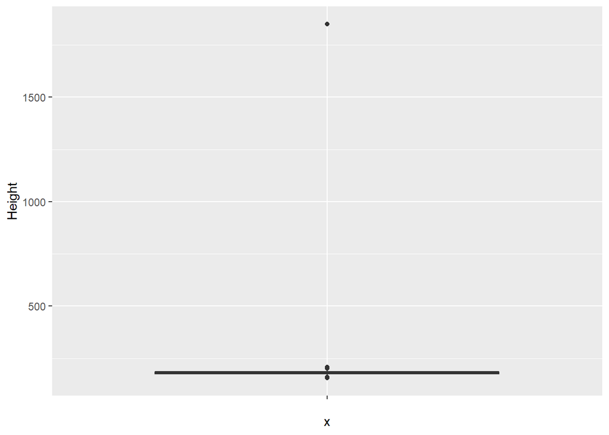

```r
# Height
ggplot(data = fifa.copy ,aes(x="",y=Height))+geom_boxplot()
```

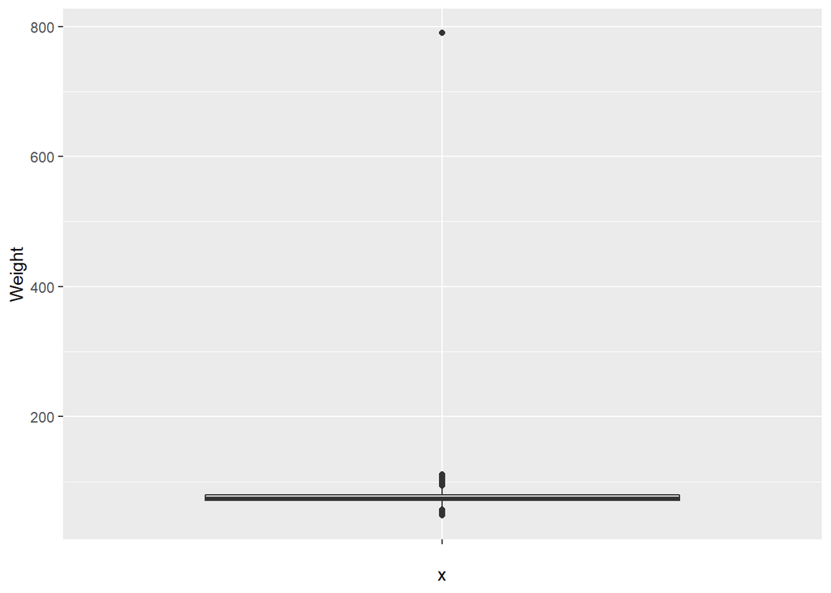

```r
# Weight
ggplot(data = fifa.copy ,aes(x="",y=Weight))+geom_boxplot()
```

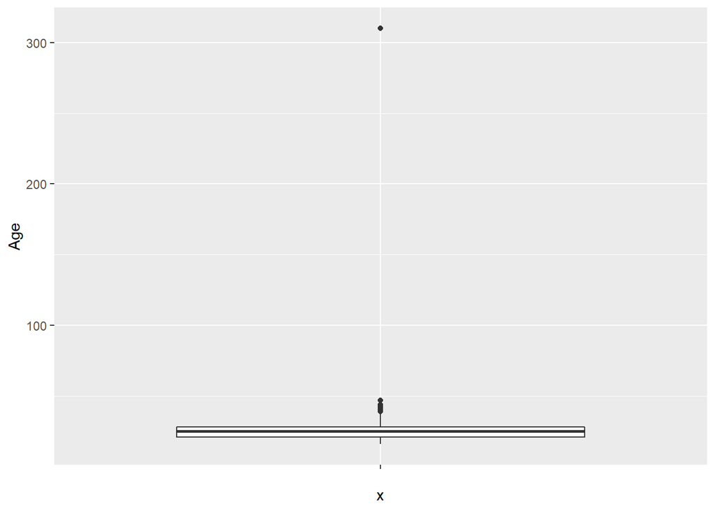

```r
# Age
ggplot(data = fifa.copy ,aes(x="",y=Age))+geom_boxplot()
```

Finalement generem la nova taula amb els nous valors de dispersió.

```r
# calculem les mesures de dispersió per a Height
height.sdev <- sd(fifa.copy$Height)
height.ric <- IQR(fifa.copy$Height)
height.ram <- mad(fifa.copy$Height)

dispersion.height.row <- c(height.sdev, height.ric, height.ram)
dispersion.height.row
```

```
## [1] 14.24442 10.00000  7.41300
```

```r
# calculem les mesures de dispersió per a Weight
weight.sdev <- sd(fifa.copy$Weight)
weight.ric <- IQR(fifa.copy$Weight)
weight.ram <- mad(fifa.copy$Weight)

dispersion.weight.row <- c(weight.sdev, weight.ric, weight.ram)
dispersion.weight.row
```

```
## [1] 8.760783 9.000000 7.413000
```

```r
# calculem les mesures de dispersió per a Age
age.sdev <- sd(fifa.copy$Age)
age.ric <- IQR(fifa.copy$Age)
age.ram <- mad(fifa.copy$Age)

dispersion.age.row <- c(age.sdev, age.ric, age.ram)

# concatenem els vectors dels càlculs per a cada atribut
vectors <- rbind(as.vector(dispersion.height.row), as.vector(dispersion.weight.row), as.vector(dispersion.age.row))

# construïm el dataset
df.dispersion <- as.data.frame(vectors)

# afegim el header names
colnames(df.dispersion)<- c('SDEV', 'IRC', 'DAM')

# afegim row names
rownames(df.dispersion)<- c('Height', 'Weight', 'Age')

df.dispersion
```

```
##             SDEV IRC    DAM
## Height 14.244423  10 7.4130
## Weight  8.760783   9 7.4130
## Age     5.145762   7 4.4478
```

Veiem clarament la robustesa de IRC i DAM que no han modificat quasi res o res del valor amb l’outlier. En canvi la desviació standard sí que s’ha vist força afectada.

Valors de dispersió sense outliers:

[output not shown]

Valors de dispersió amb outliers:

[output not shown]

# 9 Anàlisi de Components Principals (ACP)

Anem a realitzar un estudi de components principals. Aquest estudi s’acostuma a fer servir per a reduïr el nombre de variables en una mostra. El que volem és trobar el màxim valor de variança acumulada amb el menor nombre de components principals. Els components principals són noves variables que surten com una combinació lineal de les variables originals i el vector propi o eigenvector.

Si tenim molta correlació entre les variables, és a dir redundància, podrem eliminar alguna d’elles sense perdre informació de la mostra.

Per fer l’estudi, primer anem a seleccionar les variables a tractar.

```r
fifa.pca <- fifa[,c('Height', 'Weight', 'Age', 'Rating')]
```

Ara mostrarem la matriu de correlació. Quan més aprop están de 1 o -1 indica que estan fortament relacionades de forma lineal. El valor negatiu indica que al augmentar una disminueix l’altre.

```r
correlation <- cor(fifa.pca)
round(correlation, 2)
```

```
##        Height Weight  Age Rating
## Height   1.00   0.76 0.08   0.05
## Weight   0.76   1.00 0.22   0.14
## Age      0.08   0.22 1.00   0.46
## Rating   0.05   0.14 0.46   1.00
```

Com és força lògic, tenim una força relació entre el pes i l’alçada.

De forma gràfica també ho podem veure. La línea diagonal és 1 perquè és la relació amb elles mateixes.

La que té força relació, és la que hem comentat abans: Height amb Weight.

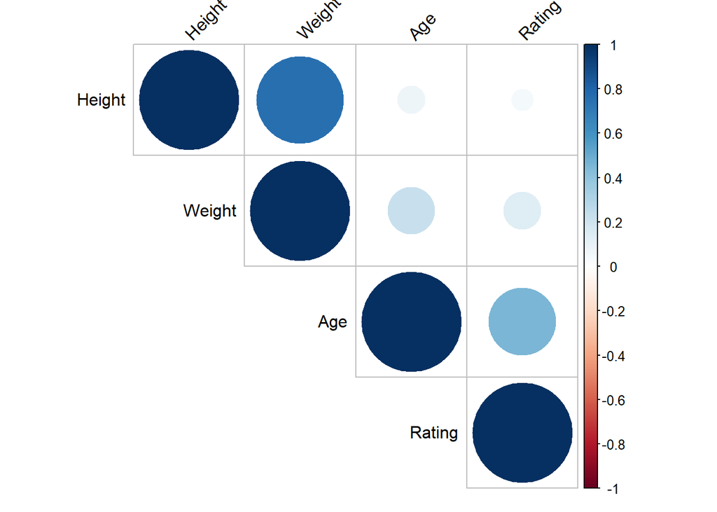

```r
corrplot(correlation, type = "upper", order = "hclust", tl.col = "black", tl.srt = 45)
```

Farem servir per a realitzar la diagonalització la matriu de correlacions, ja que tenim dades formades per magnituds diferents. El que fa és normalitzar els valors amb mitjana 0 i desviació standard 1.

```r
PCA.cor <- prcomp(x=fifa.pca, center = TRUE, scale.= TRUE)
summary(PCA.cor)
```

```
## Importance of components:
##                           PC1    PC2    PC3     PC4
## Standard deviation     1.3766 1.1540 0.7374 0.47914
## Proportion of Variance 0.4738 0.3329 0.1359 0.05739
## Cumulative Proportion  0.4738 0.8067 0.9426 1.00000
```

Amb la següent instrucció mostrem els eigenvectors per a generar les funcions per construir els nous atributs.

```r
PCA.cor$rotation
```

```
##               PC1        PC2         PC3          PC4
## Height -0.5899867  0.4128537 -0.09545363  0.687281679
## Weight -0.6406113  0.2804325  0.03019413 -0.714186989
## Age    -0.3725681 -0.5899081  0.70405486  0.132318578
## Rating -0.3205088 -0.6347581 -0.70305311  0.008522477
```

El mateix per a PC2, PC3, PC4 i per a cada un dels registres del dataset, construiriem el nou espai dimensional.

Mostrem visualment la variança que aporta cada dimensió.

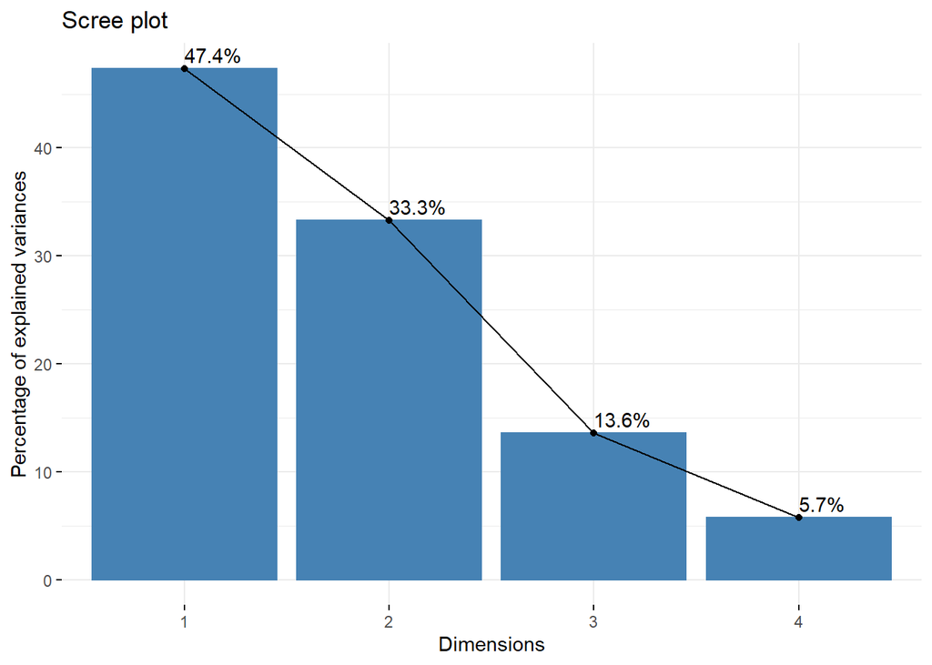

```r
# la funció mostra la variança de cada component
fviz_eig(PCA.cor, choice = c("variance"), addlabels = TRUE)
```

Veiem la contribució a la Dimensió 1 de cada variable.

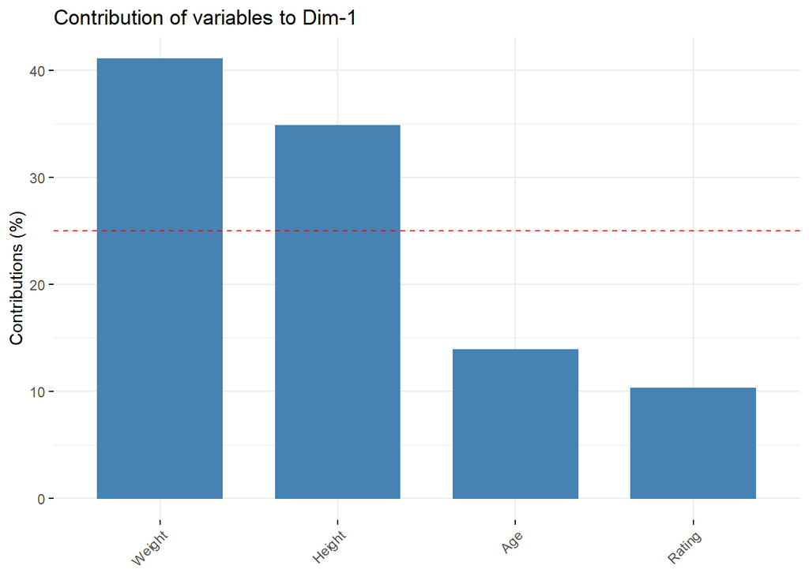

```r
fviz_contrib(PCA.cor, choice = "var", axes = 1)
```

Veiem que les que més aporten són Weight primer, seguit de Height.

Fem el mateix per la Dimensió 2.

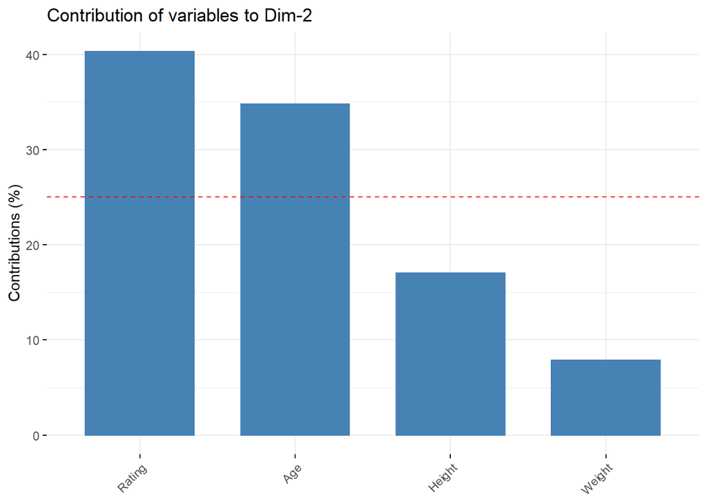

```r
fviz_contrib(PCA.cor, choice = "var", axes = 2)
```

Per a la dimensió 2 és Rating seguit de Age.

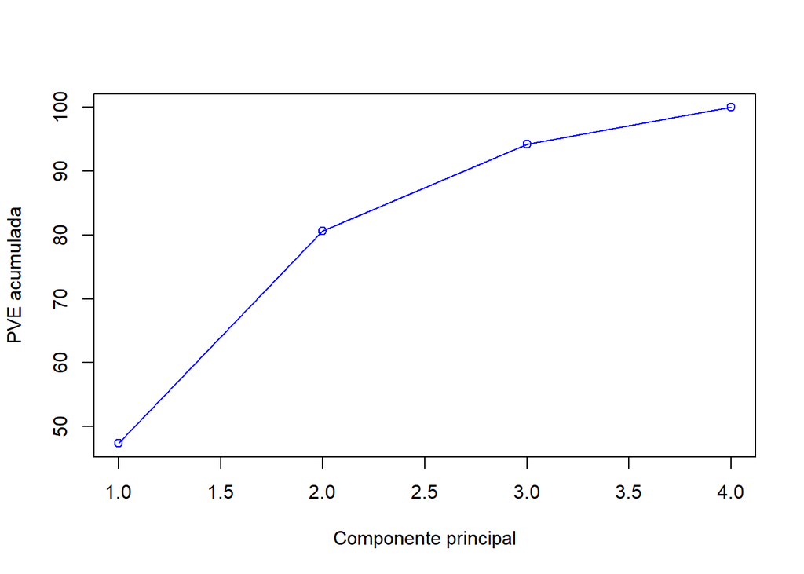

```r
# pve acumulada
PVE <- 100*PCA.cor$sdev^2/sum(PCA.cor$sdev^2)

plot(cumsum(PVE), type = "o",
     ylab = "PVE acumulada",
     xlab = "Componente principal",
     col = "blue")
```

Una altre gràfica on podem la PVE (proporció de variança acumulada).

Per a determinar amb quants components principals ens quedem. Fem servir:

- Regla de Kaiser-Guttman: escollim els PC’s on el seu eigenvalue sigui més gran que el valor mitjà (en la matriu de correlacions, aquest valor és 1).

```r
# PCA.cor$sdev és l'arrel quadrada dels valors propis, per treure els valors propis elevem al quadrat.

eigenvalues <- PCA.cor$sdev^2
eigenvalues
```

```
## [1] 1.8950125 1.3316652 0.5437462 0.2295761
```

Segons la regla Kaiser-Guttman només agafariem dos components principals.

- Scree plot. Regla del colze: mostrem gràficament els eigenvalues i on veiem un colze (baixada pronunciada) és el nostre nombre de components.

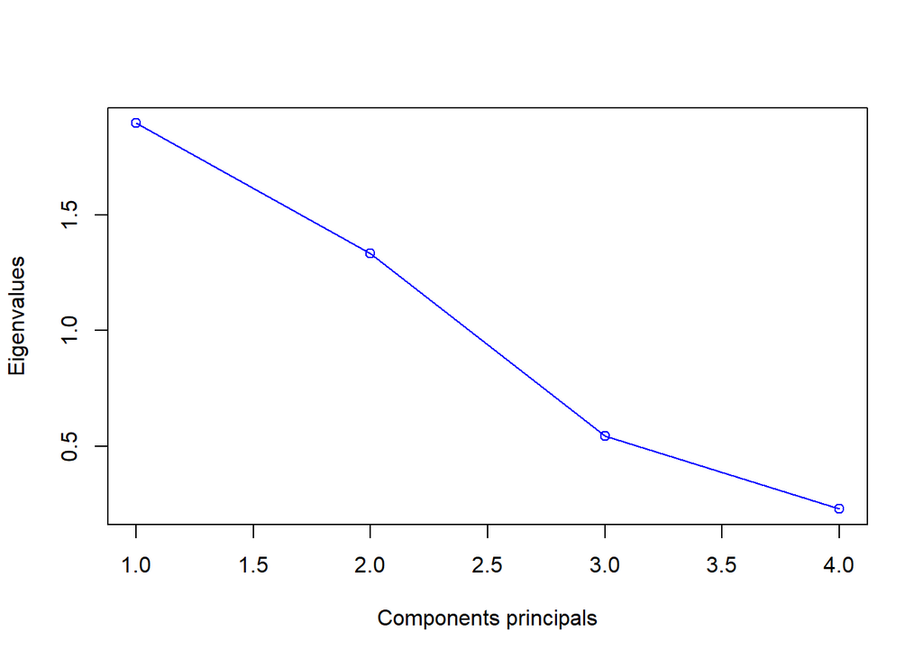

```r
plot(eigenvalues, type = "o",
     ylab = "Eigenvalues",
     xlab = "Components principals",
     col = "blue")
```

No es veu un colze tan clar, però potser escolliriem 3 components principals.

Mostrem gràficament la rellevància de les variables originals en els PC’s i l’associació entre elles. Les originals són les fletxes des de l’origen. La longitud de la fletxa indica quina rellevància te en la projecció.

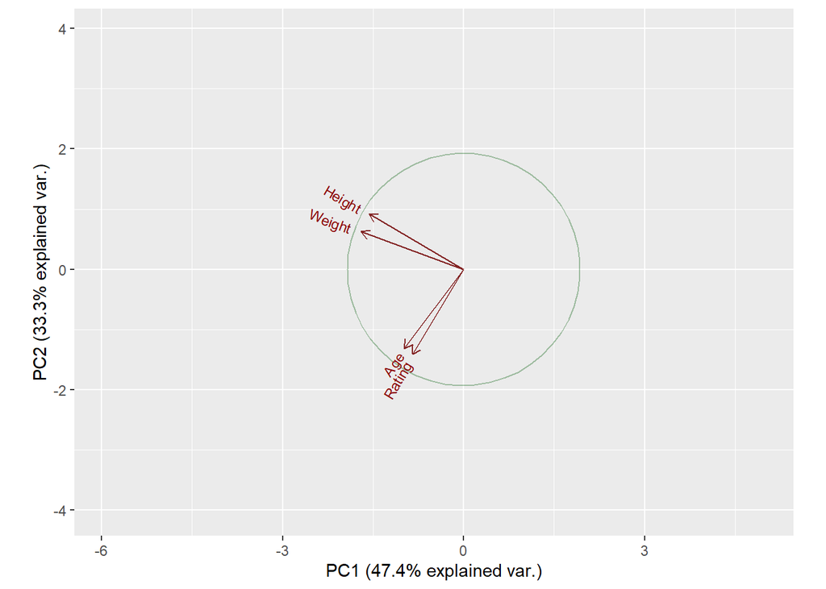

```r
ggbiplot(PCA.cor, scale = 1, obs.scale = 1, alpha=0,circle=TRUE)
```

Veiem en les fletxes la alta correlació entre les variables Height i Weight (que ja havíem comentat) i entre Age i Rating. Sembla que efectivament com ens deia la regla de Kaiser-Guttman podem fer servir només dues dimensions extretes de la correlació esmentada prèviament. I també sembla que les 4 tenen un pes semblant ja que la llargaria de les fletxes és força similar.

Si mostrem el núbol de punts podem apreciar un punt força allunyat respecte a la resta.

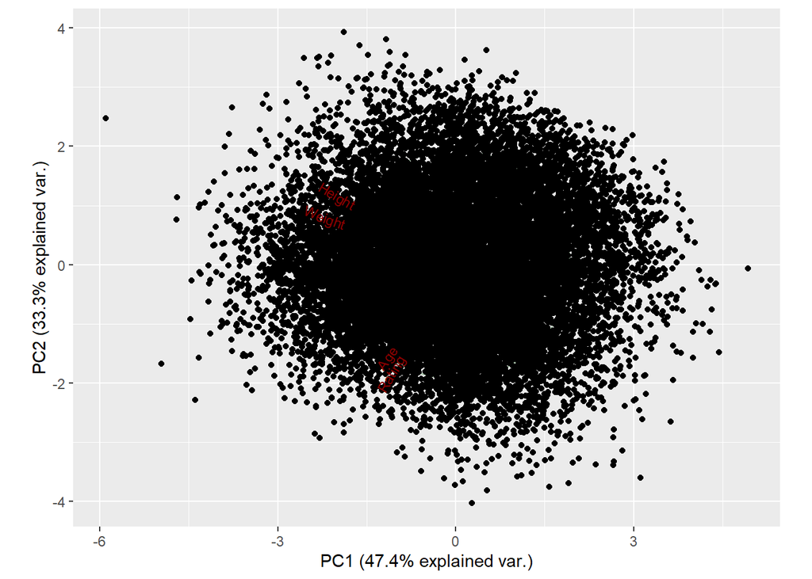

```r
ggbiplot(PCA.cor, scale = 1, obs.scale = 1, circle=TRUE)
```

# 10 Fitxer final

Guardem el dataset processat a ‘fifa_clean.csv’

```r
write.csv(fifa,"fifa_clean.csv",row.names=TRUE)
```